# Cvičenie 6: Modelovanie volatility - GARCH modely

# 1 Inštalácia knižníc v R-ku

Začneme s inštaláciou knižníc potrebných na toto cvičenie. Spustením nasledovného príkazu sa nainštalujú tie z knižníc, ktoré nainštalované nie sú, a zároveň sa aj načítajú.

```r
# názvy balíkov, ktoré budú potrebné pre cvičenie 6
packages <- c("astsa", "urca", "ggplot2", "quantmod", "fGarch")

# inštalácia balíkov, ak nie sú nainštalované
installed_packages <- packages %in% rownames(installed.packages())
if (any(installed_packages == FALSE)) {
  install.packages(packages[!installed_packages],dependencies=TRUE)
}

# načítanie balíkov
invisible(lapply(packages, library, character.only = TRUE))
```

# 2 Príklad 1: Ceny akcie Apple

V prvej časti budeme, tak ako na prednáške, pracovať s logaritmickými výnosmi akcií. Konkrétne sa pozrieme na výnosy akcie AAPL (Apple):

```r
getSymbols("AAPL",
           from = "2019-01-01",
           to = "2024-12-01",
           auto.assign = TRUE)
```

```
## [1] "AAPL"
```

Budeme pracovať s týždennými dátami.

```r
AAPL.tyzden <- to.weekly(AAPL)
head(AAPL.tyzden)
```

```
##            AAPL.Open AAPL.High AAPL.Low AAPL.Close AAPL.Volume AAPL.Adjusted
## 2019-01-04   38.7225   39.7125   35.500    37.0650   747836000      35.24256
## 2019-01-11   37.1750   38.6325   36.475    38.0725   814824400      36.20052
## 2019-01-18   37.7125   39.4700   37.305    39.2050   621168000      37.27734
## 2019-01-25   39.1025   39.5325   37.925    39.4400   450006400      37.50077
## 2019-02-01   38.9475   42.2500   38.415    41.6300   809187200      39.58311
## 2019-02-08   41.8525   43.8925   41.820    42.6025   605593600      40.68152
```

Transformácia cien na logaritmické výnosy:

```r
ceny <- AAPL.tyzden$AAPL.Adjusted
vynosy <- diff(log(ceny))
vynosy <- vynosy[-1]
```

Vykreslenie dát

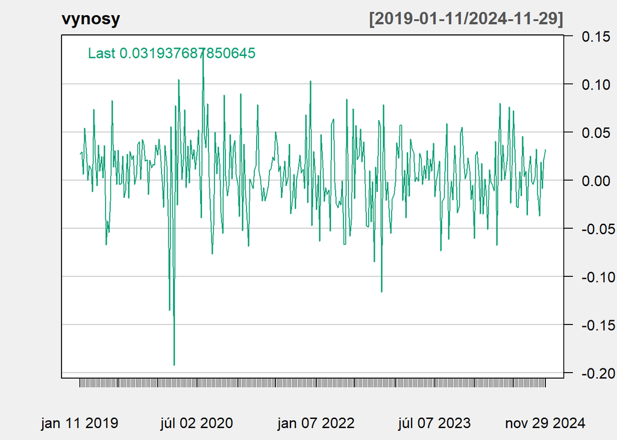

```r
chartSeries(vynosy, theme=chartTheme('white',up.col="#009E73"))
```

Skontrolujeme, či v dátch náhodou nie je jednotkový koreň

```r
summary(ur.df(vynosy, lags = 5, selectlags = "BIC", type = "none"))
```

```
##
## ###############################################
## # Augmented Dickey-Fuller Test Unit Root Test #
## ###############################################
##
## Test regression none
##
##
## Call:
## lm(formula = z.diff ~ z.lag.1 - 1 + z.diff.lag)
##
## Residuals:
##       Min        1Q    Median        3Q       Max
## -0.194703 -0.016046  0.006969  0.027720  0.137304
##
## Coefficients:
##            Estimate Std. Error t value Pr(>|t|)
## z.lag.1    -0.96414    0.08172 -11.798   <2e-16 ***
## z.diff.lag -0.03545    0.05774  -0.614     0.54
## ---
## Signif. codes:  0 '***' 0.001 '**' 0.01 '*' 0.05 '.' 0.1 ' ' 1
##
## Residual standard error: 0.03928 on 300 degrees of freedom
## Multiple R-squared:  0.4999, Adjusted R-squared:  0.4966
## F-statistic: 149.9 on 2 and 300 DF,  p-value: < 2.2e-16
##
##
## Value of test-statistic is: -11.798
##
## Critical values for test statistics:
##       1pct  5pct 10pct
## tau1 -2.58 -1.95 -1.62
```

Hypotézu o jednotkovom koreni zamietame, takže dáta nebude potrebné differencovať.

Vykreslíme si ACF a PACF pre naše dáta

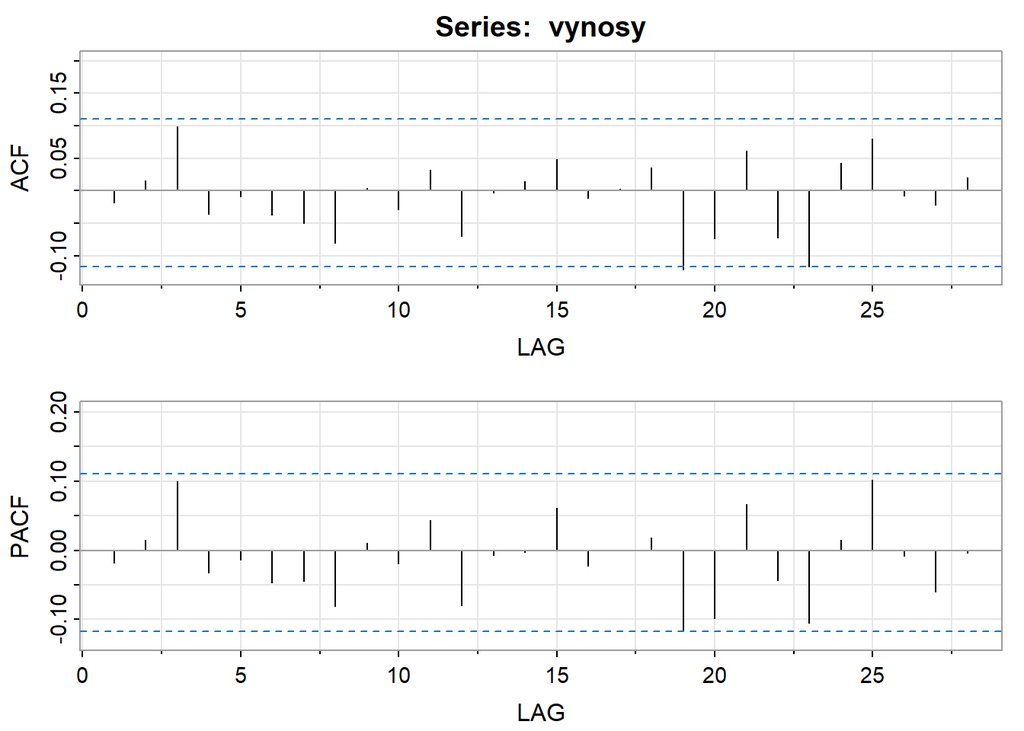

```
##       [,1] [,2] [,3]  [,4]  [,5]  [,6]  [,7]  [,8] [,9] [,10] [,11] [,12] [,13]
## ACF  -0.02 0.02  0.1 -0.04 -0.01 -0.04 -0.05 -0.08 0.00 -0.03  0.03 -0.07  0.00
## PACF -0.02 0.02  0.1 -0.03 -0.01 -0.05 -0.04 -0.08 0.01 -0.02  0.04 -0.08 -0.01
##      [,14] [,15] [,16] [,17] [,18] [,19] [,20] [,21] [,22] [,23] [,24] [,25]
## ACF   0.01  0.05 -0.01     0  0.04 -0.12 -0.07  0.06 -0.07 -0.12  0.04  0.08
## PACF  0.00  0.06 -0.02     0  0.02 -0.12 -0.10  0.07 -0.04 -0.11  0.02  0.10
##      [,26] [,27] [,28]
## ACF  -0.01 -0.02  0.02
## PACF -0.01 -0.06  0.00
```

```r
acf2(vynosy)
```

Zdá sa, že podľa ACF aj PACF by sme dáta mohli modelovať ako konštanta + biely šum.

```
## <><><><><><><><><><><><><><>
##
## Coefficients:
##       Estimate     SE t.value p.value
## xmean   0.0062 0.0022  2.8133  0.0052
##
## sigma^2 estimated as 0.001484103 on 307 degrees of freedom
##
## AIC = -3.662081  AICc = -3.662038  BIC = -3.637859
##
```

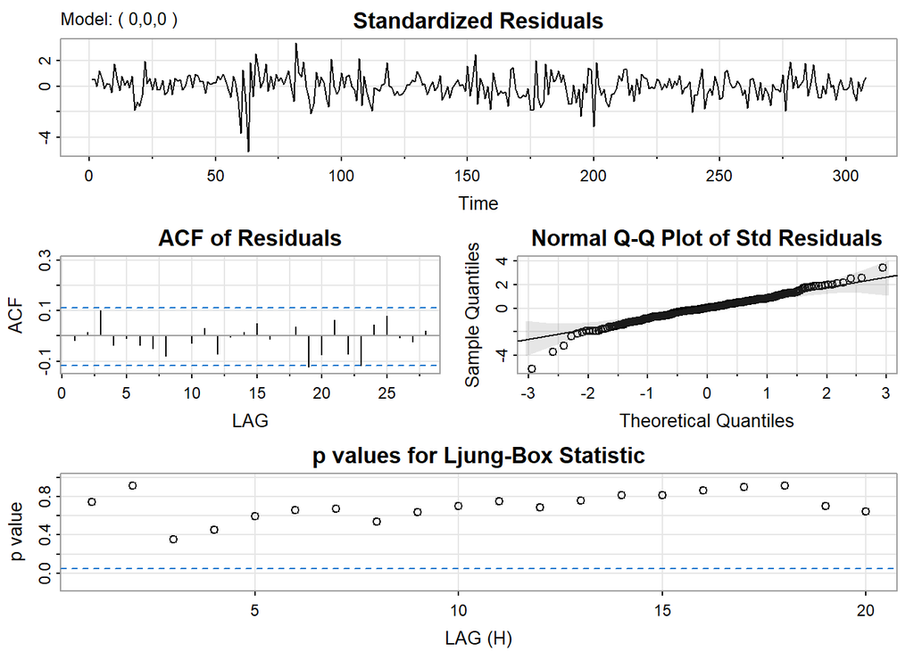

```r
vynosy.00 <- sarima(vynosy,0,0,0)
```

```r
vynosy.00
```

```
## $fit
##
## Call:
## arima(x = xdata, order = c(p, d, q), seasonal = list(order = c(P, D, Q), period = S),
##     xreg = xmean, include.mean = FALSE, transform.pars = trans, fixed = fixed,
##     optim.control = list(trace = trc, REPORT = 1, reltol = tol))
##
## Coefficients:
##        xmean
##       0.0062
## s.e.  0.0022
##
## sigma^2 estimated as 0.001484:  log likelihood = 565.96,  aic = -1127.92
##
## $sigma2
## [1] 0.001484103
##
## $degrees_of_freedom
## [1] 307
##
## $t.table
##       Estimate     SE t.value p.value
## xmean   0.0062 0.0022  2.8133  0.0052
##
## $ICs
##       AIC      AICc       BIC
## -3.662081 -3.662038 -3.637859
```

Porovnáme si ACF pre rezídua a pre ich druhé mocniny:

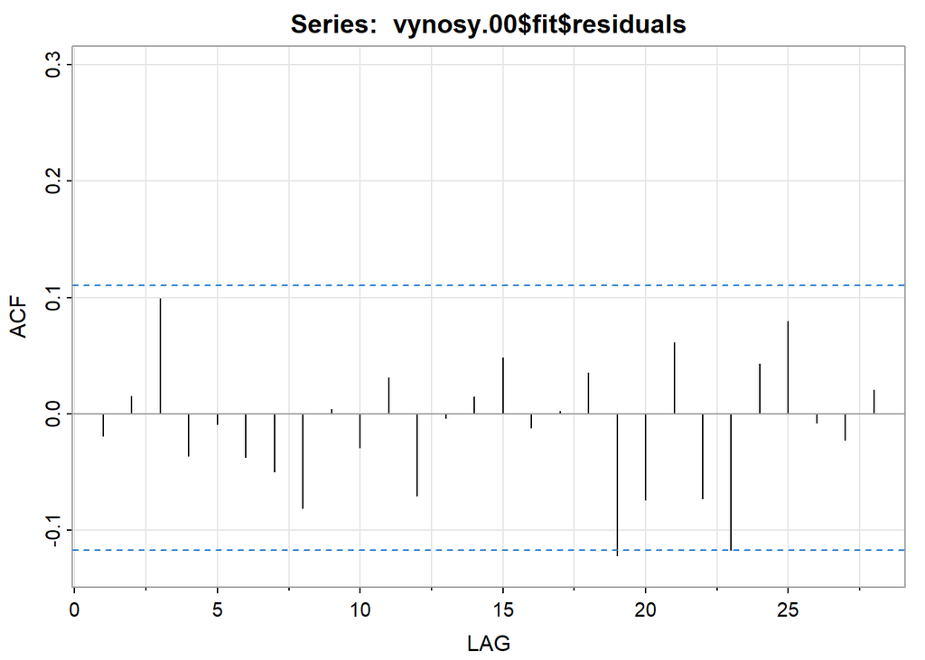

```
##  [1] -0.02  0.02  0.10 -0.04 -0.01 -0.04 -0.05 -0.08  0.00 -0.03  0.03 -0.07
## [13]  0.00  0.01  0.05 -0.01  0.00  0.04 -0.12 -0.07  0.06 -0.07 -0.12  0.04
## [25]  0.08 -0.01 -0.02  0.02
```

```r
acf1(vynosy.00$fit$residuals)
```

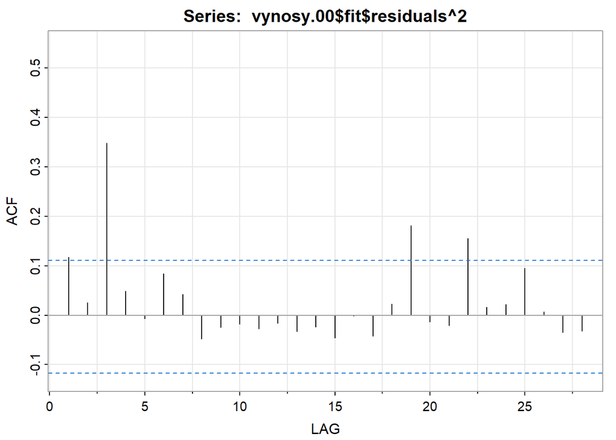

```
##  [1]  0.12  0.03  0.35  0.05 -0.01  0.08  0.04 -0.05 -0.02 -0.02 -0.03 -0.02
## [13] -0.03 -0.02 -0.05  0.00 -0.04  0.02  0.18 -0.01 -0.02  0.15  0.02  0.02
## [25]  0.10  0.01 -0.03 -0.03
```

```r
acf1(vynosy.00$fit$residuals^2)
```

Vidíme, že hoci samotné rezídua nevyzerajú byť korelované, ich druhé mocniny korelované sú. Takúto vlastnosť ale biely šum nemá. Preto budeme $u$ modelovať ako GARCH(p,q) proces.

## 2.1 ARCH(p)

Najskôr budeme dáta modelovať iba ako ARCH(p) proces. Začneme základným ARCH(1) procesom.

**Otázky:**

- Čo znamená, ak $u$ nemodelujeme ako biely šum, ale ako ARCH(p) proces? Ako vtedy modelujeme jeho disperziu?
- Aké ohraničenia na parametre musia byť splnené, aby bol ARCH(p) proces stacionárny?

V R-ku na modelovanie použijeme funkciu `garchFit` z knižnice `fGarch`:

- `~garch(1,0)` - predstavuje formulu, všeobecne v tvare `~arma(p,q)+garch(p,q)`
- `data` - naše dáta
- `trace` - ak chceme vypísať konvergenciu, atď… (FALSE ak nechceme)

```r
vynosy.10 <- garchFit(~garch(1,0), data = vynosy, trace = FALSE)
vynosy.10
```

```
##
## Title:
##  GARCH Modelling
##
## Call:
##  garchFit(formula = ~garch(1, 0), data = vynosy, trace = FALSE)
##
## Mean and Variance Equation:
##  data ~ garch(1, 0)
## <environment: 0x0000020b00d4b2e8>
##  [data = vynosy]
##
## Conditional Distribution:
##  norm
##
## Coefficient(s):
##        mu      omega     alpha1
## 0.0085720  0.0010083  0.3977711
##
## Std. Errors:
##  based on Hessian
##
## Error Analysis:
##         Estimate  Std. Error  t value Pr(>|t|)
## mu     0.0085720   0.0020253    4.232 2.31e-05 ***
## omega  0.0010083   0.0001309    7.702 1.33e-14 ***
## alpha1 0.3977711   0.1342797    2.962  0.00305 **
## ---
## Signif. codes:  0 '***' 0.001 '**' 0.01 '*' 0.05 '.' 0.1 ' ' 1
##
## Log Likelihood:
##  573.3349    normalized:  1.861477
##
## Description:
##  Thu Dec 11 12:57:07 2025 by user: Anna Hlubinová
```

Z výstupu môžeme vidieť odhady pre jednotlivé parametre:

- `mu` - konštanta v rovnici pre strednú hodnotu
- `omega` - konštanta v rovnici pre disperziu
- `alpha1` - koeficient pri $u^2_{t-1}$

Spolu s odhadmi sú dané aj štandardné odchýlky a hodnota testovej štatistiky (H0: daný koeficient je nulový) spolu s p-value.

Všetky tri koeficienty sú signifikantné.

Pozrieme sa ešte na zhodnotenie rezíduí. Dobrý model bude taký, kde nezostane žiadna autokorelácia v rezíduách ani v ich druhých mocninách a zároveň hypotéza o homoskedasticite sa nebude zamietať. K týmto hodnotám pristúpime cez funkciu `summary`, ktorá nám ponúka aj hodnotu informačných kritérií pre daný model. K tým budeme ale pristupovať neskôr.

```r
summary(vynosy.10)
```

```
##
## Title:
##  GARCH Modelling
##
## Call:
##  garchFit(formula = ~garch(1, 0), data = vynosy, trace = FALSE)
##
## Mean and Variance Equation:
##  data ~ garch(1, 0)
## <environment: 0x0000020b00d4b2e8>
##  [data = vynosy]
##
## Conditional Distribution:
##  norm
##
## Coefficient(s):
##        mu      omega     alpha1
## 0.0085720  0.0010083  0.3977711
##
## Std. Errors:
##  based on Hessian
##
## Error Analysis:
##         Estimate  Std. Error  t value Pr(>|t|)
## mu     0.0085720   0.0020253    4.232 2.31e-05 ***
## omega  0.0010083   0.0001309    7.702 1.33e-14 ***
## alpha1 0.3977711   0.1342797    2.962  0.00305 **
## ---
## Signif. codes:  0 '***' 0.001 '**' 0.01 '*' 0.05 '.' 0.1 ' ' 1
##
## Log Likelihood:
##  573.3349    normalized:  1.861477
##
## Description:
##  Thu Dec 11 12:57:07 2025 by user: Anna Hlubinová
##
##
## Standardised Residuals Tests:
##                                 Statistic p-Value
##  Jarque-Bera Test   R    Chi^2  39.98946  2.072044e-09
##  Shapiro-Wilk Test  R    W      0.9823208 0.0007576702
##  Ljung-Box Test     R    Q(10)  6.261823  0.7928072
##  Ljung-Box Test     R    Q(15)  8.932048  0.8810436
##  Ljung-Box Test     R    Q(20)  16.15907  0.7067082
##  Ljung-Box Test     R^2  Q(10)  33.6285   0.0002134508
##  Ljung-Box Test     R^2  Q(15)  35.54325  0.002056526
##  Ljung-Box Test     R^2  Q(20)  40.44114  0.004391451
##  LM Arch Test       R    TR^2   31.47018  0.001669446
##
## Information Criterion Statistics:
##       AIC       BIC       SIC      HQIC
## -3.703473 -3.667141 -3.703661 -3.688946
```

Vidíme, že stále ostáva istá autokorelácia medzi druhými mocninami rezíduí, aj keď samotné rezíduá nie sú korelované. Rovnako sa zamieta aj LM Arch test, teda zamietame hypotézu o homoskedasticite (konštantnosti disperzie v rezíduach).

**Úloha:** Zobrazte ACF pre štandardizované rezíduá a pre ich druhé mocniny.

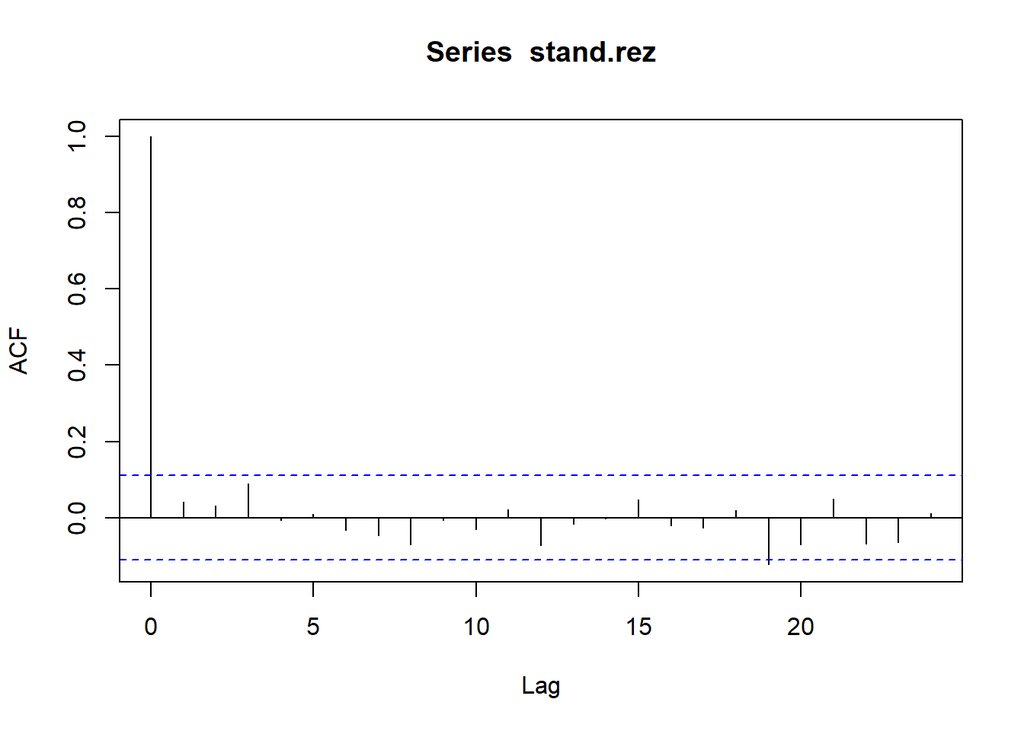

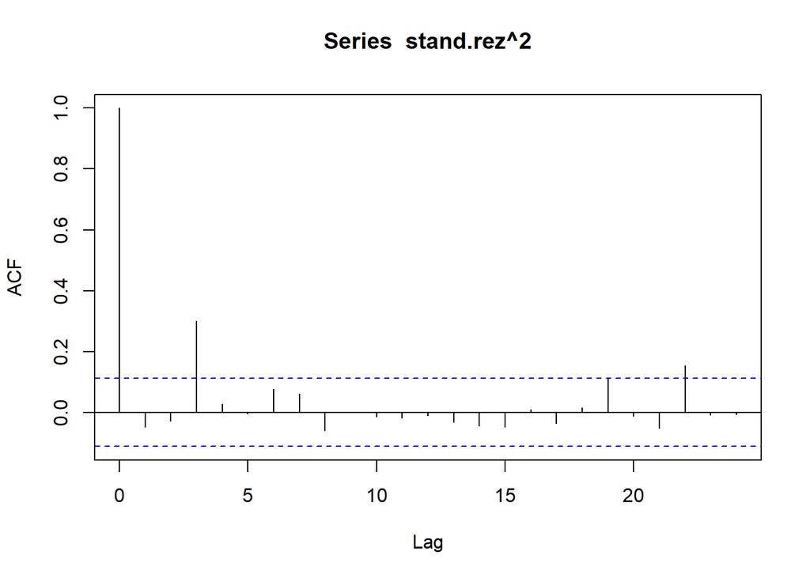

Z ACF štvorcov štandardizovaných rezíduí vidíme, že ARCH(1) nie je dobrý model. Skúsime teda zvýšiť rád ARCH procesu na ARCH(2):

```r
vynosy.20 <- garchFit(~garch(2,0), data = vynosy, trace = FALSE)
vynosy.20
```

```
##
## Title:
##  GARCH Modelling
##
## Call:
##  garchFit(formula = ~garch(2, 0), data = vynosy, trace = FALSE)
##
## Mean and Variance Equation:
##  data ~ garch(2, 0)
## <environment: 0x0000020b0f11f2e8>
##  [data = vynosy]
##
## Conditional Distribution:
##  norm
##
## Coefficient(s):
##         mu       omega      alpha1      alpha2
## 0.00866804  0.00093114  0.38156385  0.07229877
##
## Std. Errors:
##  based on Hessian
##
## Error Analysis:
##         Estimate  Std. Error  t value Pr(>|t|)
## mu     0.0086680   0.0020605    4.207 2.59e-05 ***
## omega  0.0009311   0.0001562    5.961 2.51e-09 ***
## alpha1 0.3815639   0.1338194    2.851  0.00435 **
## alpha2 0.0722988   0.0935665    0.773  0.43970
## ---
## Signif. codes:  0 '***' 0.001 '**' 0.01 '*' 0.05 '.' 0.1 ' ' 1
##
## Log Likelihood:
##  573.5904    normalized:  1.862306
##
## Description:
##  Thu Dec 11 12:57:07 2025 by user: Anna Hlubinová
```

```r
summary(vynosy.20)
```

```
##
## Title:
##  GARCH Modelling
##
## Call:
##  garchFit(formula = ~garch(2, 0), data = vynosy, trace = FALSE)
##
## Mean and Variance Equation:
##  data ~ garch(2, 0)
## <environment: 0x0000020b0f11f2e8>
##  [data = vynosy]
##
## Conditional Distribution:
##  norm
##
## Coefficient(s):
##         mu       omega      alpha1      alpha2
## 0.00866804  0.00093114  0.38156385  0.07229877
##
## Std. Errors:
##  based on Hessian
##
## Error Analysis:
##         Estimate  Std. Error  t value Pr(>|t|)
## mu     0.0086680   0.0020605    4.207 2.59e-05 ***
## omega  0.0009311   0.0001562    5.961 2.51e-09 ***
## alpha1 0.3815639   0.1338194    2.851  0.00435 **
## alpha2 0.0722988   0.0935665    0.773  0.43970
## ---
## Signif. codes:  0 '***' 0.001 '**' 0.01 '*' 0.05 '.' 0.1 ' ' 1
##
## Log Likelihood:
##  573.5904    normalized:  1.862306
##
## Description:
##  Thu Dec 11 12:57:07 2025 by user: Anna Hlubinová
##
##
## Standardised Residuals Tests:
##                                 Statistic p-Value
##  Jarque-Bera Test   R    Chi^2  38.80506  3.746177e-09
##  Shapiro-Wilk Test  R    W      0.9824344 0.000798183
##  Ljung-Box Test     R    Q(10)  6.45722   0.7754993
##  Ljung-Box Test     R    Q(15)  9.205252  0.8665431
##  Ljung-Box Test     R    Q(20)  16.66363  0.6746952
##  Ljung-Box Test     R^2  Q(10)  33.21259  0.0002508582
##  Ljung-Box Test     R^2  Q(15)  35.08424  0.002392014
##  Ljung-Box Test     R^2  Q(20)  40.54769  0.004256298
##  LM Arch Test       R    TR^2   30.39315  0.002435828
##
## Information Criterion Statistics:
##       AIC       BIC       SIC      HQIC
## -3.698639 -3.650196 -3.698970 -3.679269
```

Vidíme, že koeficient `alpha2` vyšiel nesignifikantný, zároveň sa však zachovali nedostatky rezíduí z ARCH(1) procesu (v niektorých prípadoch dokonca horšie p hodnoty).

Skúsme ARCH(3):

```r
vynosy.30 <- garchFit(~garch(3,0), data = vynosy, trace = FALSE)
vynosy.30
```

```
##
## Title:
##  GARCH Modelling
##
## Call:
##  garchFit(formula = ~garch(3, 0), data = vynosy, trace = FALSE)
##
## Mean and Variance Equation:
##  data ~ garch(3, 0)
## <environment: 0x0000020b115ebfc8>
##  [data = vynosy]
##
## Conditional Distribution:
##  norm
##
## Coefficient(s):
##         mu       omega      alpha1      alpha2      alpha3
## 0.00729294  0.00090668  0.21858809  0.00000001  0.15916385
##
## Std. Errors:
##  based on Hessian
##
## Error Analysis:
##         Estimate  Std. Error  t value Pr(>|t|)
## mu     7.293e-03   2.096e-03    3.479 0.000504 ***
## omega  9.067e-04   1.414e-04    6.411 1.45e-10 ***
## alpha1 2.186e-01   9.999e-02    2.186 0.028806 *
## alpha2 1.000e-08   6.392e-02    0.000 1.000000
## alpha3 1.592e-01   6.470e-02    2.460 0.013891 *
## ---
## Signif. codes:  0 '***' 0.001 '**' 0.01 '*' 0.05 '.' 0.1 ' ' 1
##
## Log Likelihood:
##  581.4303    normalized:  1.887761
##
## Description:
##  Thu Dec 11 12:57:07 2025 by user: Anna Hlubinová
```

```r
summary(vynosy.30)
```

```
##
## Title:
##  GARCH Modelling
##
## Call:
##  garchFit(formula = ~garch(3, 0), data = vynosy, trace = FALSE)
##
## Mean and Variance Equation:
##  data ~ garch(3, 0)
## <environment: 0x0000020b115ebfc8>
##  [data = vynosy]
##
## Conditional Distribution:
##  norm
##
## Coefficient(s):
##         mu       omega      alpha1      alpha2      alpha3
## 0.00729294  0.00090668  0.21858809  0.00000001  0.15916385
##
## Std. Errors:
##  based on Hessian
##
## Error Analysis:
##         Estimate  Std. Error  t value Pr(>|t|)
## mu     7.293e-03   2.096e-03    3.479 0.000504 ***
## omega  9.067e-04   1.414e-04    6.411 1.45e-10 ***
## alpha1 2.186e-01   9.999e-02    2.186 0.028806 *
## alpha2 1.000e-08   6.392e-02    0.000 1.000000
## alpha3 1.592e-01   6.470e-02    2.460 0.013891 *
## ---
## Signif. codes:  0 '***' 0.001 '**' 0.01 '*' 0.05 '.' 0.1 ' ' 1
##
## Log Likelihood:
##  581.4303    normalized:  1.887761
##
## Description:
##  Thu Dec 11 12:57:07 2025 by user: Anna Hlubinová
##
##
## Standardised Residuals Tests:
##                                 Statistic p-Value
##  Jarque-Bera Test   R    Chi^2  15.44965  0.0004417251
##  Shapiro-Wilk Test  R    W      0.9885062 0.01539709
##  Ljung-Box Test     R    Q(10)  6.680369  0.7552361
##  Ljung-Box Test     R    Q(15)  10.5195   0.7858535
##  Ljung-Box Test     R    Q(20)  17.02054  0.6516397
##  Ljung-Box Test     R^2  Q(10)  4.958093  0.8939598
##  Ljung-Box Test     R^2  Q(15)  6.576988  0.9683438
##  Ljung-Box Test     R^2  Q(20)  8.100053  0.9911849
##  LM Arch Test       R    TR^2   4.664792  0.968249
##
## Information Criterion Statistics:
##       AIC       BIC       SIC      HQIC
## -3.743054 -3.682501 -3.743570 -3.718842
```

Opäť máme nesignifikantný koeficient `alpha2`, no druhé mocniny rezíduí sú už bez výraznej autokorelácie, LM Arch test sa tiež nezamietol, teda môžeme predpokladať konštatnú disperziu v rezíduách.

ACF štandardizovaných rezíduí a ich druhé mocniny vyzerajú nasledovne:

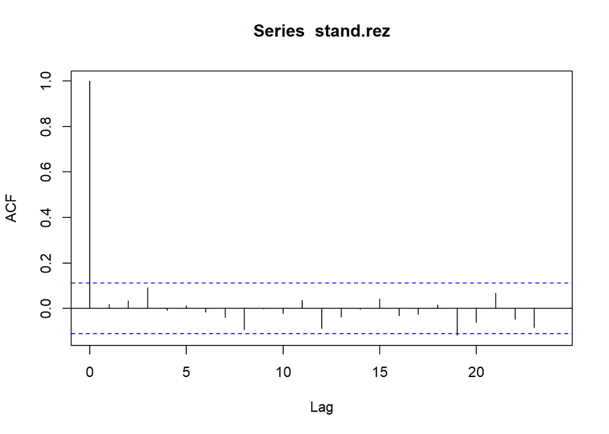

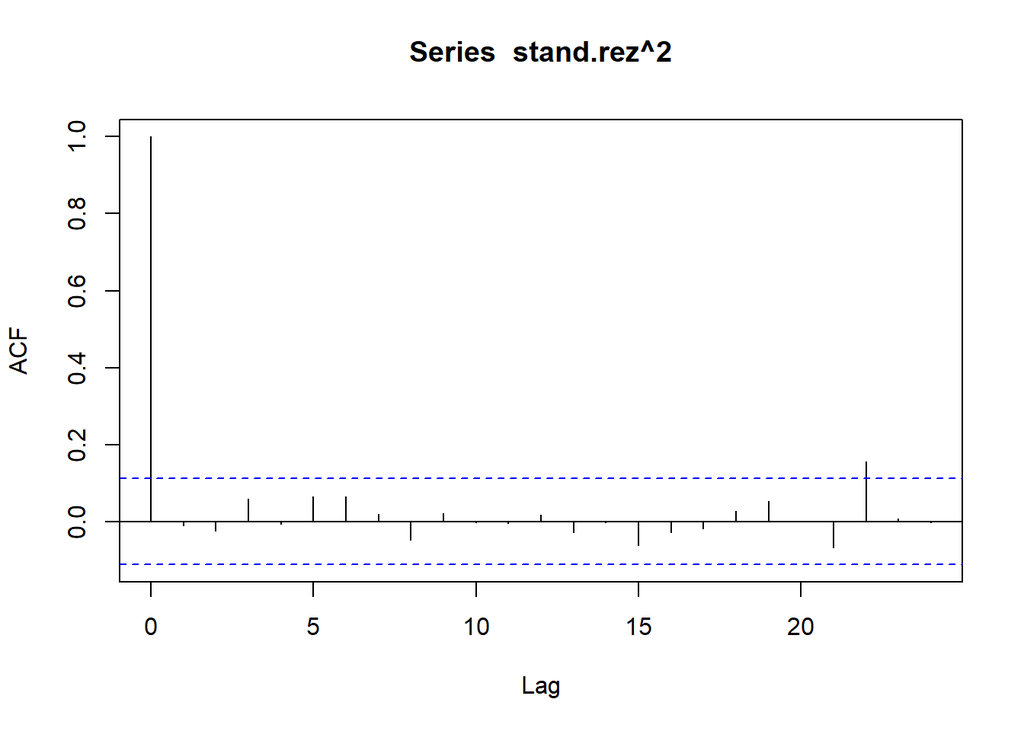

## 2.2 GARCH(p,q)

ARCH(3) proces vyšiel ako vhodný model pre naše dáta, avšak vyšiel nám v ňom koeficient `alpha2` nesignifikantný. Preto sa pozrieme aj na zovšeobecnený ARCH proces, GARCH. Skúsime začať základným, ktorý sa vo veľa prípadoch ukazuje ako dostatočný na modelovanie volatility. Je ním GARCH(1,1) proces.

**Otázky:**

- Čo znamená, ak $u$ nemodelujeme ako biely šum, ale ako GARCH(p,q) proces? Ako vtedy modelujeme jeho disperziu?
- Aké ohraničenia na parametre musia byť splnené, aby bol GARCH(p,q) proces stacionárny?

Modelujme v R-ku:

```r
vynosy.11 <- garchFit(~garch(1,1), data = vynosy, trace = FALSE)
vynosy.11
```

```
##
## Title:
##  GARCH Modelling
##
## Call:
##  garchFit(formula = ~garch(1, 1), data = vynosy, trace = FALSE)
##
## Mean and Variance Equation:
##  data ~ garch(1, 1)
## <environment: 0x0000020b133a5c58>
##  [data = vynosy]
##
## Conditional Distribution:
##  norm
##
## Coefficient(s):
##        mu      omega     alpha1      beta1
## 0.0082960  0.0002866  0.2274886  0.5938766
##
## Std. Errors:
##  based on Hessian
##
## Error Analysis:
##         Estimate  Std. Error  t value Pr(>|t|)
## mu     0.0082960   0.0020551    4.037 5.42e-05 ***
## omega  0.0002866   0.0001199    2.390  0.01686 *
## alpha1 0.2274886   0.0869570    2.616  0.00889 **
## beta1  0.5938766   0.1234122    4.812 1.49e-06 ***
## ---
## Signif. codes:  0 '***' 0.001 '**' 0.01 '*' 0.05 '.' 0.1 ' ' 1
##
## Log Likelihood:
##  579.4267    normalized:  1.881256
##
## Description:
##  Thu Dec 11 12:57:08 2025 by user: Anna Hlubinová
```

```r
summary(vynosy.11)
```

```
##
## Title:
##  GARCH Modelling
##
## Call:
##  garchFit(formula = ~garch(1, 1), data = vynosy, trace = FALSE)
##
## Mean and Variance Equation:
##  data ~ garch(1, 1)
## <environment: 0x0000020b133a5c58>
##  [data = vynosy]
##
## Conditional Distribution:
##  norm
##
## Coefficient(s):
##        mu      omega     alpha1      beta1
## 0.0082960  0.0002866  0.2274886  0.5938766
##
## Std. Errors:
##  based on Hessian
##
## Error Analysis:
##         Estimate  Std. Error  t value Pr(>|t|)
## mu     0.0082960   0.0020551    4.037 5.42e-05 ***
## omega  0.0002866   0.0001199    2.390  0.01686 *
## alpha1 0.2274886   0.0869570    2.616  0.00889 **
## beta1  0.5938766   0.1234122    4.812 1.49e-06 ***
## ---
## Signif. codes:  0 '***' 0.001 '**' 0.01 '*' 0.05 '.' 0.1 ' ' 1
##
## Log Likelihood:
##  579.4267    normalized:  1.881256
##
## Description:
##  Thu Dec 11 12:57:08 2025 by user: Anna Hlubinová
##
##
## Standardised Residuals Tests:
##                                 Statistic p-Value
##  Jarque-Bera Test   R    Chi^2  24.1595   5.673247e-06
##  Shapiro-Wilk Test  R    W      0.9861116 0.00460023
##  Ljung-Box Test     R    Q(10)  6.941253  0.7309791
##  Ljung-Box Test     R    Q(15)  10.87402  0.7614729
##  Ljung-Box Test     R    Q(20)  18.26829  0.5697396
##  Ljung-Box Test     R^2  Q(10)  12.60091  0.246849
##  Ljung-Box Test     R^2  Q(15)  14.65496  0.4765445
##  Ljung-Box Test     R^2  Q(20)  18.14541  0.5778299
##  LM Arch Test       R    TR^2   11.22309  0.5099025
##
## Information Criterion Statistics:
##       AIC       BIC       SIC      HQIC
## -3.736537 -3.688094 -3.736869 -3.717168
```

Všetky koeficienty vyšli signifikatné. Testy nezamietli nulovú koreláciu medzi rezíduami, ani medzi ich druhými mocninami, nezamietol sa ani LM Arch test pre homoskedasticitu v rezíduách. Teda, tak ako ARCH(3), aj GARCH(1,1) je pre naše dáta dobrým modelom.

Na ukážku ešte vyskúšame GARCH proces vyššieho rádu napríklad GARCH(1,2).

```r
vynosy.12 <- garchFit(~garch(1,2), data = vynosy, trace = FALSE)
vynosy.12
```

```
##
## Title:
##  GARCH Modelling
##
## Call:
##  garchFit(formula = ~garch(1, 2), data = vynosy, trace = FALSE)
##
## Mean and Variance Equation:
##  data ~ garch(1, 2)
## <environment: 0x0000020b08c7dc70>
##  [data = vynosy]
##
## Conditional Distribution:
##  norm
##
## Coefficient(s):
##         mu       omega      alpha1       beta1       beta2
## 0.00778462  0.00039411  0.27333569  0.01587225  0.45291559
##
## Std. Errors:
##  based on Hessian
##
## Error Analysis:
##         Estimate  Std. Error  t value Pr(>|t|)
## mu     0.0077846   0.0019951    3.902 9.55e-05 ***
## omega  0.0003941   0.0001900    2.074  0.03806 *
## alpha1 0.2733357   0.0900406    3.036  0.00240 **
## beta1  0.0158723   0.1304444    0.122  0.90315
## beta2  0.4529156   0.1546610    2.928  0.00341 **
## ---
## Signif. codes:  0 '***' 0.001 '**' 0.01 '*' 0.05 '.' 0.1 ' ' 1
##
## Log Likelihood:
##  581.7533    normalized:  1.888809
##
## Description:
##  Thu Dec 11 12:57:08 2025 by user: Anna Hlubinová
```

```r
summary(vynosy.12)
```

```
##
## Title:
##  GARCH Modelling
##
## Call:
##  garchFit(formula = ~garch(1, 2), data = vynosy, trace = FALSE)
##
## Mean and Variance Equation:
##  data ~ garch(1, 2)
## <environment: 0x0000020b08c7dc70>
##  [data = vynosy]
##
## Conditional Distribution:
##  norm
##
## Coefficient(s):
##         mu       omega      alpha1       beta1       beta2
## 0.00778462  0.00039411  0.27333569  0.01587225  0.45291559
##
## Std. Errors:
##  based on Hessian
##
## Error Analysis:
##         Estimate  Std. Error  t value Pr(>|t|)
## mu     0.0077846   0.0019951    3.902 9.55e-05 ***
## omega  0.0003941   0.0001900    2.074  0.03806 *
## alpha1 0.2733357   0.0900406    3.036  0.00240 **
## beta1  0.0158723   0.1304444    0.122  0.90315
## beta2  0.4529156   0.1546610    2.928  0.00341 **
## ---
## Signif. codes:  0 '***' 0.001 '**' 0.01 '*' 0.05 '.' 0.1 ' ' 1
##
## Log Likelihood:
##  581.7533    normalized:  1.888809
##
## Description:
##  Thu Dec 11 12:57:08 2025 by user: Anna Hlubinová
##
##
## Standardised Residuals Tests:
##                                 Statistic p-Value
##  Jarque-Bera Test   R    Chi^2  15.46688  0.0004379356
##  Shapiro-Wilk Test  R    W      0.9884899 0.01526823
##  Ljung-Box Test     R    Q(10)  6.77417   0.7465788
##  Ljung-Box Test     R    Q(15)  10.6311   0.7782801
##  Ljung-Box Test     R    Q(20)  17.3718   0.6287161
##  Ljung-Box Test     R^2  Q(10)  6.623587  0.7604383
##  Ljung-Box Test     R^2  Q(15)  8.747997  0.8903209
##  Ljung-Box Test     R^2  Q(20)  10.53101  0.9574906
##  LM Arch Test       R    TR^2   5.773234  0.9270788
##
## Information Criterion Statistics:
##       AIC       BIC       SIC      HQIC
## -3.745151 -3.684598 -3.745667 -3.720939
```

Vhodný model pre naše dáta môžeme zvoliť napríklad podľa informačných kritérií, ku ktorým vieme pristúpiť nasledovne.

```r
vynosy.30@fit$ics # ARCH(3)
```

```
##       AIC       BIC       SIC      HQIC
## -3.743054 -3.682501 -3.743570 -3.718842
```

```r
vynosy.11@fit$ics # GARCH(1,1)
```

```
##       AIC       BIC       SIC      HQIC
## -3.736537 -3.688094 -3.736869 -3.717168
```

```r
vynosy.12@fit$ics # GARCH(1,2)
```

```
##       AIC       BIC       SIC      HQIC
## -3.745151 -3.684598 -3.745667 -3.720939
```

Vidíme, že spomedzi troch modelov, ktoré boli pre naše dáta vyhovujúce, má najmenšiu hodnotu BIC práve GARCH(1,1). Ten ďalej použijeme aj na predikcie z modelu.

Predtým však overme stacionaritu nájdeného modelu.

GARCH(p,q) model je stacionárny, ak platí
$$(\alpha_1 + \alpha_2 + \dots + \alpha_p) + ( \beta_1 + \beta_2 + \dots +
\beta_q) <1$$
V našom prípade sú odhadnuté koeficienty nasledovné

```r
vynosy.11@fit$coef
```

```
##           mu        omega       alpha1        beta1
## 0.0082960295 0.0002865974 0.2274885791 0.5938766351
```

Teda

```r
sum(vynosy.11@fit$coef[3:4]) < 1
```

```
## [1] TRUE
```

Odhadnutý model je stacionárny.

## 2.3 Predikcie

Podobne ako pri Holt-Wintersovej metóde, predikcie budeme robiť pomocou funkcie `predict`.

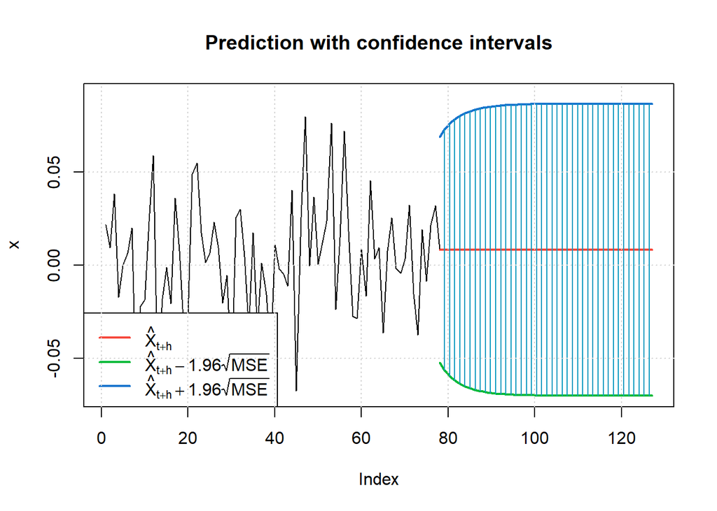

```r
vynosy.pred11 <- predict(vynosy.11, n.ahead = 50, plot = TRUE)
```

Keďže dáta modelujeme ako konštantu plus biely šum, predikcie do budúcnosti bude tiež iba samotná konštanta. Na druhú stranu, môžeme vidieť, že podmienená disperzia postupne narastá a konverguje k nepodmienenej disperzii časového radu. Prejaví sa to tak, že sa nám postupne rozšírujú intervaly spoľahlivosti.

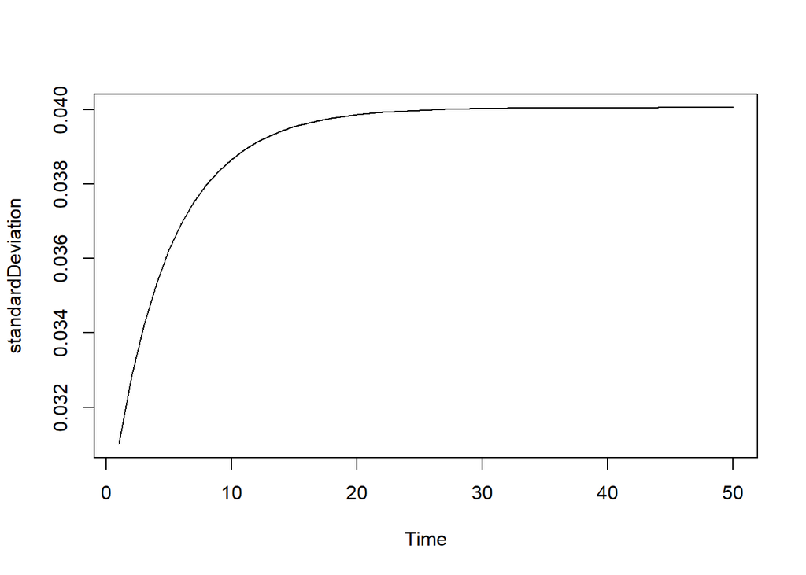

```r
plot(ts(vynosy.pred11[3]))
```

**Zhrnutie:**

- Ak sa pozeráme len na korelácie rezíduí, konštanta plus biely šum vyzerá ako dobrý model pre tieto dáta.
- Ak sa však pozrieme na druhé mocniny rezíduí z takéhoto modelu, mali by byť nekorelované, ale nie sú. To nasvedčuje tomu, že disperzia nie je konštantná.
- Ak modelujeme disperziu ARCH procesmi, potrebujeme vyšší počet parametrov na to, aby mal model dobré rezíduá, ale tieto parametre nie sú signifikantné.
- Ak modelujeme disperziu GARCH procesmi, stačí nám menej parametrov a výjdu signifikantné.

Samozrejme, **nie je to univerzálny postup** a pri iných dátach môže byť vhodnejší ARCH model bez GARCH členov, alebo pri vyhovujúcom modeli zostanú nejaké parametre nesignifikantné.

# 3 Príklad 2: Výmenný kurz: PLN/EUR

Pozrime sa teraz na dáta o výmenných kurzoch. Dáta sú za obdobie 3 rokov (od 13.12.2021 do 10.12.2024), voľne dostupné na stránke https://www.ecb.europa.eu/stats/policy_and_exchange_rates/euro_reference_exchange_rates/html/index.en.html

Stiahnuté dáta upravené na logaritmické výnosy si do R-ka môžete načítať príkazom

```r
data <- read.csv("https://anna-hlubinova.github.io/eurofx_log_returns.csv",
                 header = TRUE, sep=";")
head(data)
```

```
##         Date          USD          JPY BGN CYP          CZK       DKK EEK
## 1 13.12.2021  0.000443439 -0.000078000   0  NA  0.001418272  0.00e+00  NA
## 2 14.12.2021  0.002744944  0.002026185   0  NA -0.002641176  0.00e+00  NA
## 3 15.12.2021 -0.004164642 -0.001558240   0  NA -0.002489874  0.00e+00  NA
## 4 16.12.2021  0.006549276  0.008695032   0  NA  0.000435187  0.00e+00  NA
## 5 17.12.2021 -0.000529427 -0.008461141   0  NA -0.001068524  2.69e-05  NA
## 6 20.12.2021 -0.005043589 -0.002341373   0  NA -0.000831864 -1.34e-05  NA
##            GBP          HUF LTL LVL MTL          PLN ROL          RON
## 1 -0.002310675  0.004067432  NA  NA  NA  0.002122499  NA  0.000000000
## 2  0.002193511 -0.000599520  NA  NA  NA  0.001707721  NA  0.000000000
## 3 -0.004285931  0.006087472  NA  NA  NA -0.000604935  NA -0.000020200
## 4 -0.001707741  0.000406322  NA  NA  NA  0.000129660  NA  0.000101019
## 5  0.004387133 -0.004533062  NA  NA  NA  0.001252511  NA  0.000060600
## 6 -0.000035200 -0.002396972  NA  NA  NA  0.000021600  NA -0.000303070
##            SEK SIT SKK          CHF          ISK          NOK          HRK
```

[output cut: 34 more lines]

Budeme modelovať výmenný kurz PLN/EUR, teda štrnásty stĺpec.

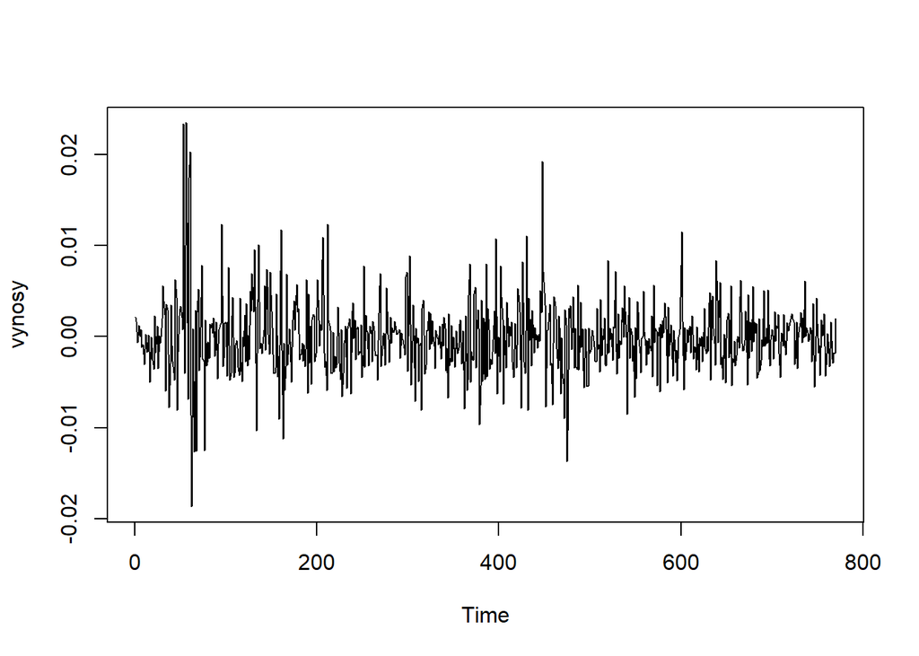

```r
vynosy <- as.ts(data[,14])
plot(vynosy)
```

Otestujeme prítomnosť jednotkového koreňa

```
##
## ###############################################
## # Augmented Dickey-Fuller Test Unit Root Test #
## ###############################################
##
## Test regression none
##
##
## Call:
## lm(formula = z.diff ~ z.lag.1 - 1 + z.diff.lag)
##
## Residuals:
##        Min         1Q     Median         3Q        Max
## -0.0169828 -0.0023207 -0.0002984  0.0017972  0.0232015
##
## Coefficients:
##             Estimate Std. Error t value Pr(>|t|)
## z.lag.1     -0.94833    0.06203 -15.288  < 2e-16 ***
## z.diff.lag1  0.03217    0.04902   0.656  0.51188
## z.diff.lag2 -0.10189    0.03607  -2.824  0.00486 **
## ---
## Signif. codes:  0 '***' 0.001 '**' 0.01 '*' 0.05 '.' 0.1 ' ' 1
##
## Residual standard error: 0.003986 on 761 degrees of freedom
## Multiple R-squared:  0.4824, Adjusted R-squared:  0.4804
## F-statistic: 236.4 on 3 and 761 DF,  p-value: < 2.2e-16
##
##
## Value of test-statistic is: -15.2875
##
## Critical values for test statistics:
##       1pct  5pct 10pct
## tau1 -2.58 -1.95 -1.62
```

Test zamieta hypotézu o jednotkovom koreni, teda dáta nebude potrebné diferencovať.

Ako vidno z vykreslenia logaritmických výnosov, dáta pozostávajú z viacerých období väčšej a menšej volatility.

Zobrazte ACF a PACF pre naše dáta

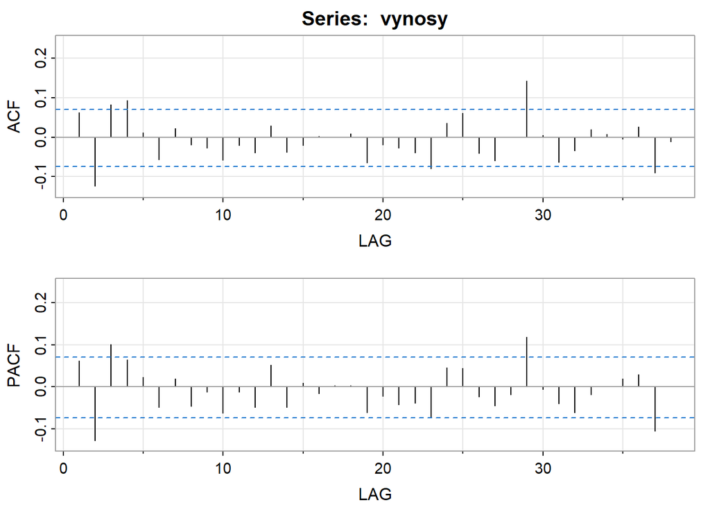

```
##      [,1]  [,2] [,3] [,4] [,5]  [,6] [,7]  [,8]  [,9] [,10] [,11] [,12] [,13]
## ACF  0.06 -0.12 0.08 0.09 0.01 -0.06 0.02 -0.02 -0.03 -0.06 -0.02 -0.04  0.03
## PACF 0.06 -0.13 0.10 0.07 0.02 -0.05 0.02 -0.05 -0.01 -0.06 -0.01 -0.05  0.05
##      [,14] [,15] [,16] [,17] [,18] [,19] [,20] [,21] [,22] [,23] [,24] [,25]
## ACF  -0.04 -0.02  0.00     0  0.01 -0.06 -0.02 -0.03 -0.04 -0.08  0.04  0.06
## PACF -0.05  0.01 -0.02     0  0.00 -0.06 -0.02 -0.04 -0.04 -0.07  0.05  0.04
##      [,26] [,27] [,28] [,29] [,30] [,31] [,32] [,33] [,34] [,35] [,36] [,37]
## ACF  -0.04 -0.06  0.00  0.14  0.00 -0.06 -0.03  0.02  0.01  0.00  0.03 -0.09
## PACF -0.02 -0.04 -0.02  0.12 -0.01 -0.04 -0.06 -0.02  0.00  0.02  0.03 -0.11
##      [,38]
## ACF  -0.01
## PACF  0.00
```

Skúsme dáta modelovať ako biely šum.

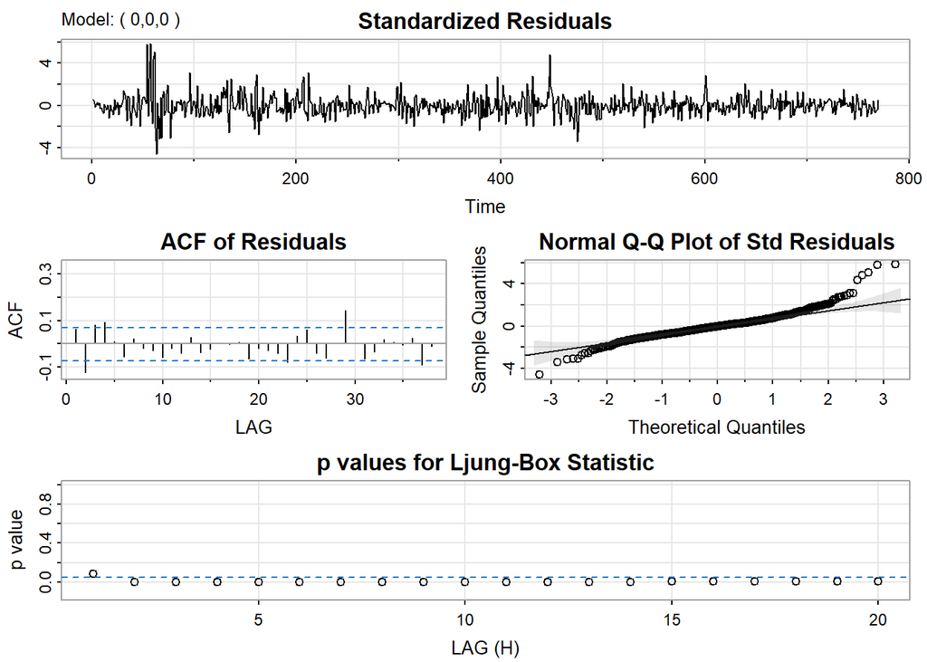

```
##  [1] "initial  value -5.515437 "
##  [2] "iter   1 value -5.515437"
##  [3] "final  value -5.515437 "
##  [4] "converged"
##  [5] "initial  value -5.515437 "
##  [6] "iter   1 value -5.515437"
##  [7] "final  value -5.515437 "
##  [8] "converged"
##  [9] "<><><><><><><><><><><><><><>"
## [10] " "
## [11] "Coefficients: "
## [12] "      Estimate    SE t.value p.value"
## [13] "xmean   -1e-04 1e-04 -0.6747  0.5001"
## [14] ""
## [15] "sigma^2 estimated as 1.619393e-05 on 769 degrees of freedom "
## [16] " "
## [17] "AIC = -8.187802  AICc = -8.187795  BIC = -8.175734 "
## [18] " "
```

V tomto prípade sa samotný časový rad nedá považovať za biely šum posunutý o konštantu. V ACF aj PACF pozorujeme autokorelácie mimo intervalov spoľahlivosti. Rovnako nevychádzajú ani Ljung-Boxové testy.

Poďme teda hľadať ďalej.

## 3.1 ARMA model

Nájdite pre dáta dobrý ARMA model. Z dobrých modelov vyberte ten s najnižším BIC. Zobrazte rezíduá a ich druhé mocniny.

Výstup pre kontrolu:

```
## <><><><><><><><><><><><><><>
##
## Coefficients:
##       Estimate     SE t.value p.value
## ar1     0.0833 0.0358  2.3229  0.0204
## ar2    -0.1343 0.0356 -3.7702  0.0002
## ar3     0.1010 0.0358  2.8212  0.0049
## xmean  -0.0001 0.0002 -0.6618  0.5083
##
## sigma^2 estimated as 1.570516e-05 on 766 degrees of freedom
##
## AIC = -8.21057  AICc = -8.210502  BIC = -8.180398
##
```

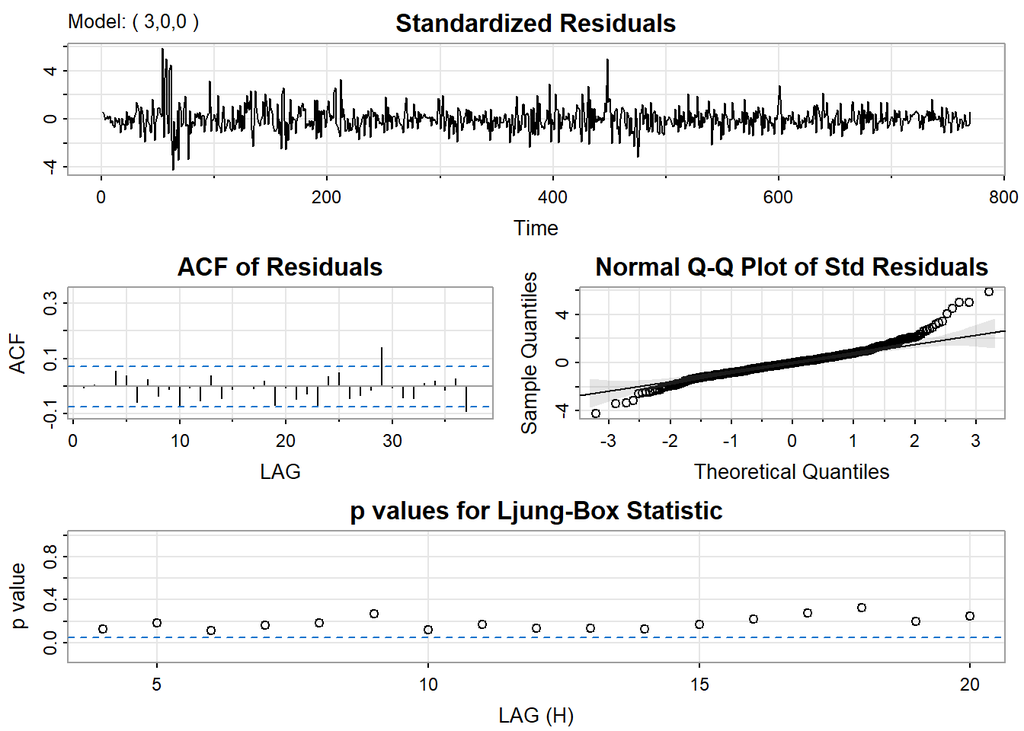

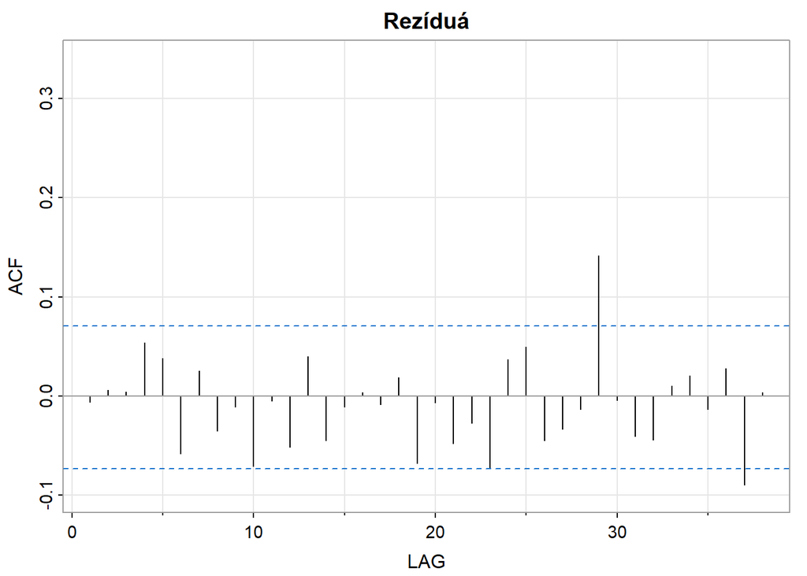

```
##  [1] -0.01  0.01  0.00  0.05  0.04 -0.06  0.03 -0.04 -0.01 -0.07  0.00 -0.05
## [13]  0.04 -0.04 -0.01  0.00 -0.01  0.02 -0.07 -0.01 -0.05 -0.03 -0.07  0.04
## [25]  0.05 -0.05 -0.03 -0.01  0.14  0.00 -0.04 -0.04  0.01  0.02 -0.01  0.03
## [37] -0.09  0.00
```

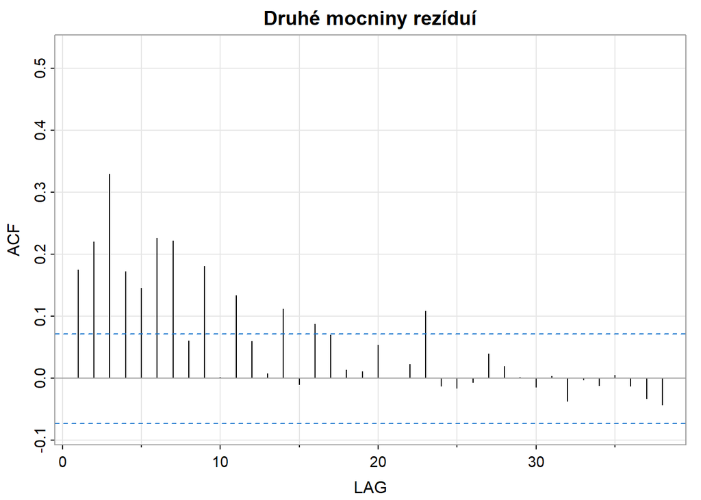

```
##  [1]  0.17  0.22  0.33  0.17  0.15  0.23  0.22  0.06  0.18  0.00  0.13  0.06
## [13]  0.01  0.11 -0.01  0.09  0.07  0.01  0.01  0.05  0.00  0.02  0.11 -0.01
## [25] -0.02 -0.01  0.04  0.02  0.00 -0.01  0.00 -0.04  0.00 -0.01  0.00 -0.01
## [37] -0.03 -0.04
```

Vidíme, že zatiaľ, čo autokorelačná funkcia pre rezíduá je v poriadku (výrazne vytŕčajú dve hodnoty, čo nemusí byť veľký problém), druhé mocniny rezíduí sú evidentne korelované.

## 3.2 GARCH

Nájdite pre dáta vhodné GARCH modely.

**Poznámka: Ak sa nejedná o čisto GARCH model, nie je dobré najskôr samostantne určiť rád členov ARMA procesu a potom dourčiť rád GARCH procesu, a to z dôvodu, že tieto dve rovnice sú navzájom prepojené, keďže v oboch by vystupovali nejaké rovnaké predošlé hodnot $u_{t-s}$.**

Ak vám vyšlo viacero dobrých modelov, vyberte najlepší na základe BIC.

## 3.3 Predikcie

Rovnako ako pri výnosoch akcií, spravíme aj teraz predikcie pre výnosy výmenných kurzov 12 dní dopredu.

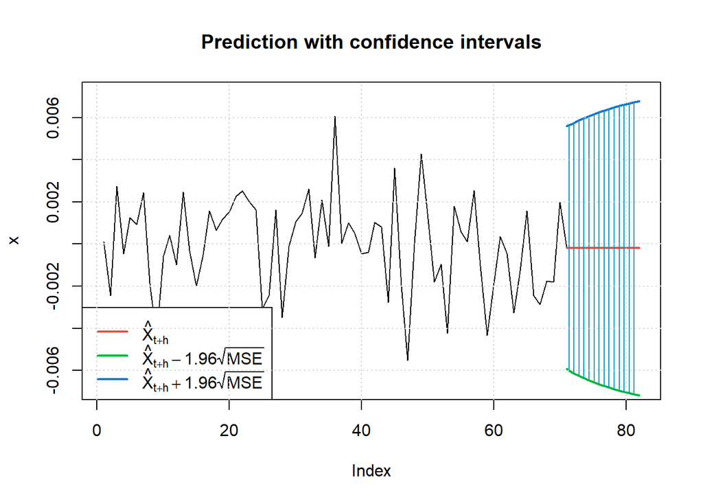

# 4 Value at Risk (VaR)

**Value at Risk (VaR)** predstavuje mieru rizika, ktorá nám hovorí, aké najväčšie straty môžeme očakávať s pravdepodobnosťou $1- \alpha$ v nasledujúcom období, kde $\alpha$ je zvolená hladina pravdepodobnosti (napr. 0.05 alebo 0.01). Ide teda o kvantifikáciu rizika vo forme určitej maximálnej straty za predpokladu, že nenastane situácia v „chvoste“ rozdelenia.

Označme $X$ hodnotu portfólia v nejakom čase. Potom $\text{VaR}_\alpha$ je definovaná ako taká hodnota, pre ktorú platí
$$P(X \le \text{VaR}_\alpha) = \alpha.$$

**Poznámka:** VaR má svoje nedostatky, ako bolo spomenuté na prednáške. Jedným z nedostatkov je fakt, že VaR hovorí iba o maximálnej očakávanej strate na úrovni pravdepodobnosti $1-\alpha$, ale neinformuje nás o priemernej veľkosti strát, ktoré sú väčšie ako $\text{VaR}_\alpha$. Na tento účel slúži metrika Conditional VaR (CVaR) alebo Expected Shortfall.

## 4.1 Výpočet VaR pre Apple akcie

Výpočet VaR si ukážeme na cenách akcie Apple, pre ktoré sme vyššie odhadli GARCH(1,1) model.

```r
ceny <- AAPL.tyzden$AAPL.Adjusted
vynosy <- diff(log(ceny))
vynosy <- vynosy[-1]
```

VaR budeme počítať iteračne. Začneme po $N=60$ hodnotách výnosov. Každý deň odhadneme GARCH(1,1) model pre naše dáta. Následne spravíme predikciu pre štandardnú odchýlku a pomocou nej zostrojíme VaR pre výnos na nasledujúci deň. Odhadovať budeme vždy z posledných 60 pozorovaní.

```r
N <- 60
var.aaple <- rep(0, length(vynosy) - N + 1)
for(i in 1:length(var.aaple))
{
  data.aapl <- vynosy[i:(i+N-1)]
  garch.aapl <- garchFit(~garch(1,1), data = data.aapl, trace = FALSE)
  aapl.pred <- predict(garch.aapl, n.ahead = 1, plot = FALSE)
  var.aaple[i] <- qnorm(0.05, mean = aapl.pred[1,1], sd = aapl.pred[1,3])
}
```

Vytvoríme z výnosov aj z VaR časové rady. VaR začína až od N+1 dňa.

```r
vynosy <- ts(vynosy)
var.aaple <- ts(var.aaple, start = N + 1)
```

Vykreslíme do jedného grafu

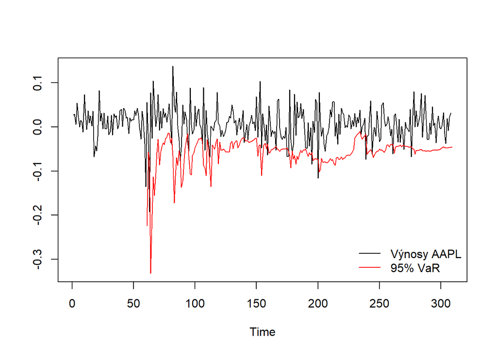

```r
ts.plot(vynosy, var.aaple, col=c("black", "red"), lty = c(1, 1))
legend("bottomright", legend = c("Výnosy AAPL", "95% VaR"), col = c("black", "red"),lty = c(1, 1), bty = "n")
```

Vypočítajte počet prekročení VaR:

```
## [1] 18
```

Percentuálne:

```
## [1] 7.258065
```

Vidíme, že frekvencia prekorčení je viac ako 5%, teda náš model nemusí byť najvhodnejší na výpočet Value at risk . Rovnako by ešte trebalo testovať, či sú jednotlivé prekročenia od seba nezávislé.

## 4.2 Testovanie VaR

### 4.2.1 Kupiecov test

Kupiecov test (angl. Kupiec’s test), často známy aj ako *proportion of failures test*, je štatistická metóda používaná na overenie správnosti odhadu Value at Risk (VaR) modelu. Tento test overuje, či je frekvencia porušení VaR (t. j. prípadov, keď reálna strata prekročí odhadovaný VaR) konzistentná s očakávanou pravdepodobnosťou porušenia, ktorá je $\alpha$ (signifikantná hladina, napr. 5 % pre 95 % VaR).

Definujme funkciu $I(\alpha) = \sum_{t=0}^n I_t(\alpha)$, kde $I_t(\alpha)$ je rovné 1 ak $r_t < \text{VaR}_t(\alpha)$, inak je $I_t(\alpha)$ rovné 0. Pozorovanú frekvenciu prekročení vieme potom spočítať ako $\hat{\alpha}= \frac{I(\alpha)}{n}$. Ďalej predpokladáme, že prekročenia sú nezávislé z alternativného rozdelenia s parametrom $\alpha$. Potom počet prekročení má binomické rozdelenie.

Myšlienka Kupiecovho testu:
$$H_0: \alpha = \hat{\alpha} \quad \text{vs.} \quad H_1: \alpha \ne
\hat{\alpha}.$$

Ak platí nulová hypotéza, potom likelihood-ratio štatistika má hodnotu
$$\text{LR}_{pof} = 2 \ln \Big[ \Big( \frac{1- \hat{\alpha}}{1- \alpha}
\Big) ^ {n-I(\alpha)} \Big( \frac{\hat{\alpha}}{\alpha}\Big)
^{I(\alpha)} \Big] \sim \chi_1^2$$

Testujte pomocou Kupiecovho testu prekročenia Value at Risk:

```r
freq <- ...
celkovy.pocet <- ...

LRuc <- 2*log(... )

pchisq(..., df = ..., lower.tail = FALSE)
```

```
## [1] 0.1252441
```

P-value testu vyšla výrazne viac ako 5%, a preto nulovú hypotézu nezamietame. Teda aj keď pozorovaná frekvencia vyšla vyššia ako 5%, je to pravdepodobne iba štatistická chyba a môžeme vyhlásiť, že frekvencia prekročení je zhodná s predefinovanou hladinou VaR.

### 4.2.2 Christoffersenov test

Aj sériovo závislé prekročenia nám robia problém. Zhlukovanie prekročení môže spôsobiť, že dva dni po sebe budeme pozorovať straty, na ktoré nebudeme kapitálovo pripravení. Preto je dôležité, aby platila nezávislosť prekročení.

Majme proces prekročení $I_t$, ktorý môžeme modelovať ako Markovský reťazec:
$$\pi_{ij} = P(I_t(\alpha) = j \mid I_{t-1}(\alpha) = i).$$

Nech $N_{ij}$ je počet pozorovaní v stave $j$, ak v predošlej perióde bolo v stave $i$ a označme $N_0 = N_{00} + N_{01}$ a $N_1 = N_{11} + N_{10}.$

Ďalej označme odhad pravdepodobností prechodu zo stavov ako $\pi_{01}$ a $\pi_{11}$, ktoré vieme spočítať nasledovne
$$\hat{\pi}_{01} = \frac{N_{01}}{N_{01} + N_{00}}, \quad \hat{\pi}_{11} =
\frac{N_{11}}{N_{11} + N_{10}}.$$
Hypotézu o nezávislosti môžeme sformulovať ako:

$$H_0 : \pi_{01} = \pi_{11} = \pi \quad \text{vs} \quad H_1 : \pi_{01}
\neq \pi_{11}.$$

Za platnosti nulovej hypotézy dostávame likelihood ratio štatistiku:

$$LR_{ind} = -2 \ln \left( \frac{(1 - \pi)^{N_{0}} \pi^{N_{1}}}{(1 -
\pi_{01})^{N_{00}} \pi_{01}^{N_{01}} (1 - \pi_{11})^{N_{10}}
\pi_{11}^{N_{11}}} \right) \sim \chi^2_1,$$

kde $\hat{\pi}$ môžeme odhadnúť ako:

$$\hat{\pi} = \frac{N_{01} + N_{11}}{N_{00} + N_{10} + N_{01} + N_{11}}.$$

```r
prekrocenia <- (vynosy[(N + 1):length(vynosy)] < var.aaple[-length(var.aaple)])*1

# 2 x 0 za sebou
N00 <- sum( ? )
N01 <- sum( ? )
N10 <- sum( ? )
N11 <- sum( ? )


N0 <- ?
N1 <- ?


p01 <- ?
p11 <- ?
p <- ?


LRind <- -2*log( ? )

LRind


pchisq(?, df = ?, lower.tail = FALSE)
```

```
## [1] 0.7606419
```

P-hodnota testu vyšla aj v tomto prípade vysoko nad 5 percent, teda nulovú hypotézu opäť nezamietame. Prekročenia sú sériovo nezávislé.